# R Notebook

First, we load the relevant libraries and then update the filepath and load the three data sources.

```r
# load libraries
library(data.table)
library(lubridate)
```

```r
library(leaflet)
library(ggplot2)
library(imputeTS)
# specify folder path
folder_path <- '/Users/Jonas/Library/Mobile Documents/com~apple~CloudDocs/Documents/MBD/01. Term 1/Programming R/00. GA/'
```

```r
# load data
solar_data <- readRDS(file.path(folder_path, 'solar_dataset.RData'))
additional_variables <- readRDS(file.path(folder_path, 'additional_variables.RData'))
station_info <- fread(file.path(folder_path,'station_info.csv'))
```

Station Energy Production

(file: solar_data)

First, we analyze the data about the energy output of each 98 solar stations. We starting by checking for missing values and see that there are no missing values.

```r
# drop empty rows which need to be predicted in this project
solar_data <- solar_data[Date <= 20071231]

# find missing values
sapply(data.table(sapply(solar_data[,2:99], is.na)), sum)
```

```
## ACME ADAX ALTU APAC ARNE BEAV BESS BIXB BLAC BOIS BOWL BREC BRIS BUFF BURB BURN
##    0    0    0    0    0    0    0    0    0    0    0    0    0    0    0    0
## BUTL BYAR CAMA CENT CHAN CHER CHEY CHIC CLAY CLOU COOK COPA DURA ELRE ERIC EUFA
##    0    0    0    0    0    0    0    0    0    0    0    0    0    0    0    0
## FAIR FORA FREE FTCB GOOD GUTH HASK HINT HOBA HOLL HOOK HUGO IDAB JAYX KENT KETC
##    0    0    0    0    0    0    0    0    0    0    0    0    0    0    0    0
## LAHO LANE MADI MANG MARE MAYR MCAL MEDF MEDI MIAM MINC MTHE NEWK NINN NOWA OILT
##    0    0    0    0    0    0    0    0    0    0    0    0    0    0    0    0
## OKEM OKMU PAUL PAWN PERK PRYO PUTN REDR RETR RING SALL SEIL SHAW SKIA SLAP SPEN
##    0    0    0    0    0    0    0    0    0    0    0    0    0    0    0    0
## STIG STIL STUA SULP TAHL TALI TIPT TISH VINI WASH WATO WAUR WEAT WEST WILB WIST
##    0    0    0    0    0    0    0    0    0    0    0    0    0    0    0    0
## WOOD WYNO
##    0    0
```

To group by month and year, we convert the date to an as.Date format and create new columns for month and year.

```r
# convert Date column to date format
solar_data$Date <- as.Date(strptime(solar_data$Date, format = '%Y%m%d'))
solar_data$Month <- floor_date(solar_data$Date, 'month')
solar_data$Year <- floor_date(solar_data$Date, 'year')
```

Next, we want to check the distribution of energy production of each station. We take the mean of each of the 98 columns of the stations.

The boxplot shows that the data is equally distributed around the mean. Both the lower and upper quartile have a similar distance from the mean, and likewise do the whiskers.

There are two outliers which we investigate in more detail. These are the stations KENT (18.70 MJ) and BOIS (18.69 MJ), which are around 0.7 megajoule higher than the next highest station HOOK (18.04 MJ). This difference seems very small, but they are considered outliers since the energy production of the other stations is so similar.

```r
# find mean of each solar output column
station_mean <- solar_data[, sapply(.SD, mean, na.rm = TRUE), .SDcols = colnames(solar_data[,2:99])]
station_mean <- data.table(station = colnames(solar_data[,2:99]), mean_production = station_mean)
station_mean <- station_mean[order(-mean_production)]

# print quantiles
print(quantile(station_mean$mean_production))
```

```
##       0%      25%      50%      75%     100%
## 14795921 15973880 16403119 17033738 18700559
```

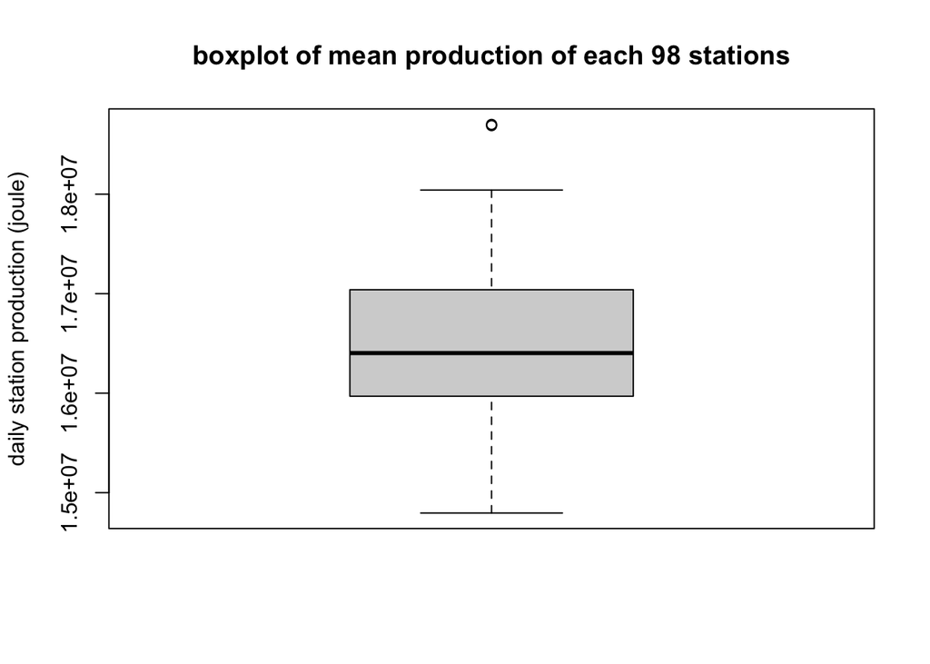

```r
# boxplot
boxplot(station_mean$mean_production,
        ylab = 'daily station production (joule)',
        main = 'boxplot of mean production of each 98 stations')
```

```r
# investigate outlier
head(station_mean)
```

| station | mean_production |
| --- | --- |
| KENT | 18700559 |
| BOIS | 18688943 |
| HOOK | 18041483 |
| HOLL | 17988184 |
| GOOD | 17943530 |
| TIPT | 17739361 |

Next, we want to investigate how energy production changes over time. First, we start by looking at the daily production of the ACME station for the year 1994. We see that there are extremely high fluctuations from day to day. This is likely due to weather changes.

We also see a season trend. Plotting the monthly mean over the year shows in summer, the production on average is 2.5 times as high as in winter.

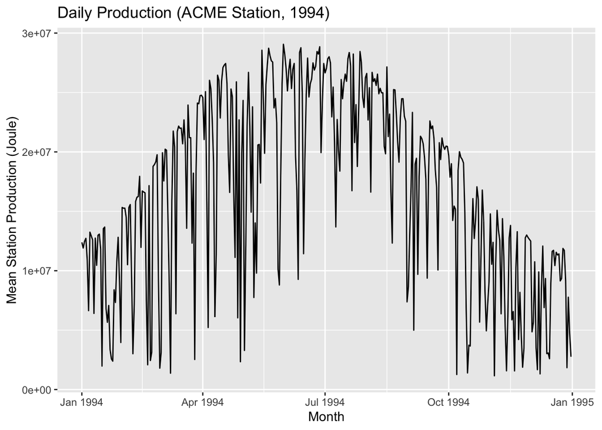

```r
# plot daily solar production over one year
plot_daily_production_one_year <- ggplot(
  solar_data[solar_data$Date < '1995-01-01'],
  aes(x = Date, y = ACME))
plot_daily_production_one_year <- plot_daily_production_one_year + geom_line()
plot_daily_production_one_year <- plot_daily_production_one_year + labs(
  title = 'Daily Production (ACME Station, 1994)',
  x = 'Month',
  y = 'Mean Station Production (Joule)')

print(plot_daily_production_one_year)
```

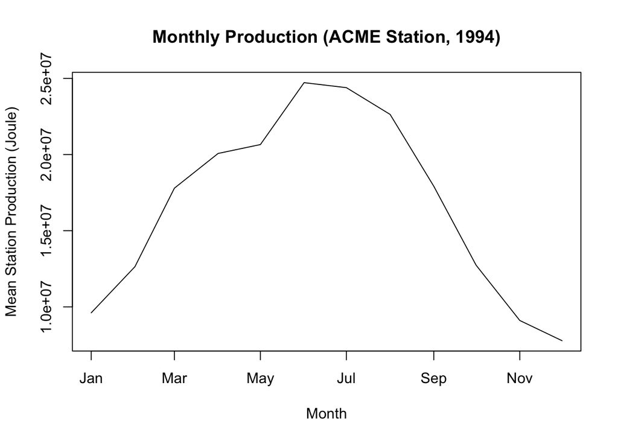

```r
# plot monthly solar production over one year
plot(x = solar_data[Date < '1995-01-01', list(ACME = mean(ACME)), by = Month]$Month,
     y = solar_data[Date < '1995-01-01', list(ACME = mean(ACME)), by = Month]$ACME,
     type = 'l',
     main = 'Monthly Production (ACME Station, 1994)',
     ylab = 'Mean Station Production (Joule)',
     xlab = 'Month')
```

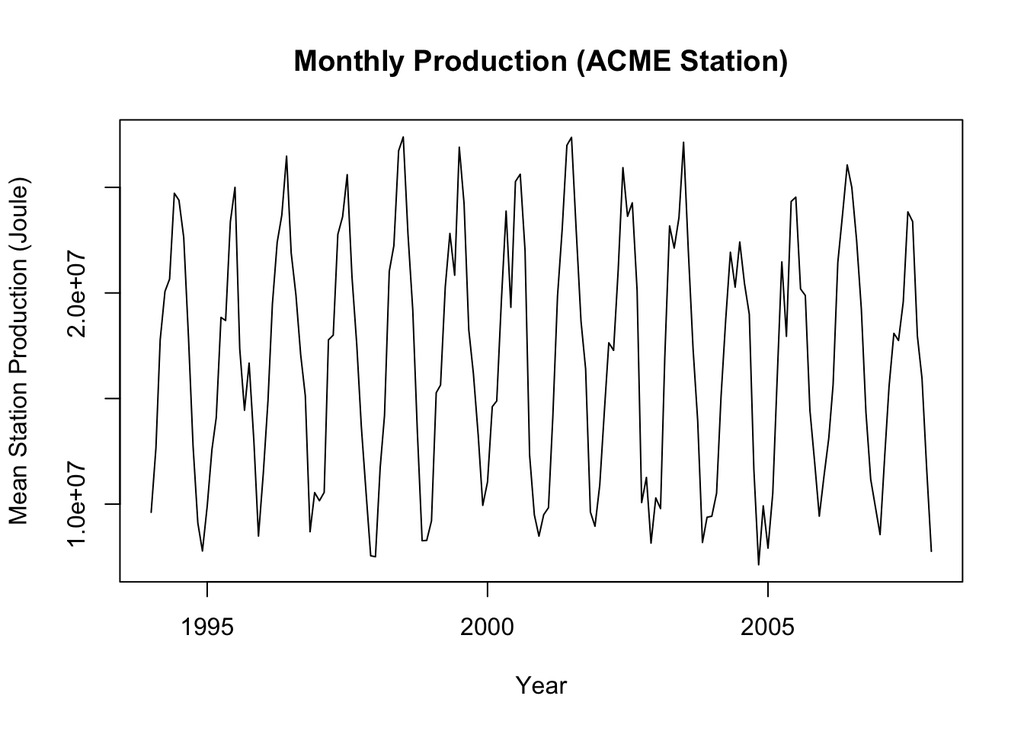

```r
# plot monthly solar production over all years
plot(x = solar_data[, list(ACME = mean(ACME)), by = Month]$Month,
     y = solar_data[, list(ACME = mean(ACME)), by = Month]$ACME,
     type = 'l',
     main = 'Monthly Production (ACME Station)',
     ylab = 'Mean Station Production (Joule)',
     xlab = 'Year')
```

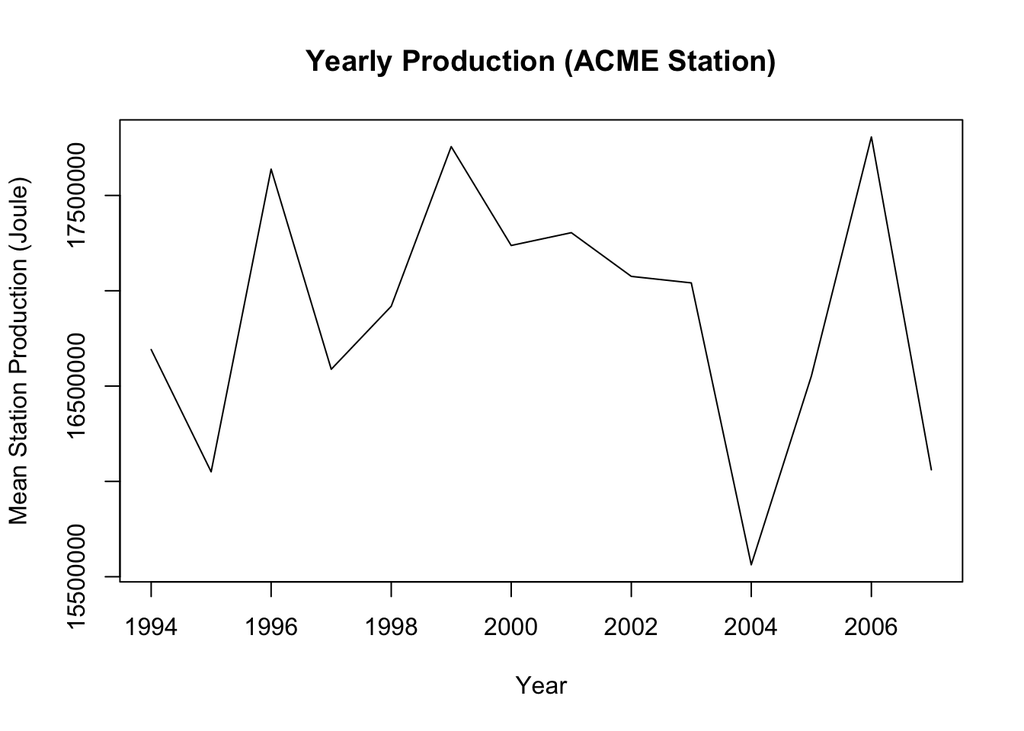

```r
# plot yearly solar production over all years
plot(x = solar_data[, list(ACME = mean(ACME)), by = Year]$Year,
     y = solar_data[, list(ACME = mean(ACME)), by = Year]$ACME,
     type = 'l',
     main = 'Yearly Production (ACME Station)',
     ylab = 'Mean Station Production (Joule)',
     xlab = 'Year')
```

Since we previously only looked at one station, we want to do the same analysis, but taking the mean across all stations. We see that the results are a bit smoother, but the results are the same overall.

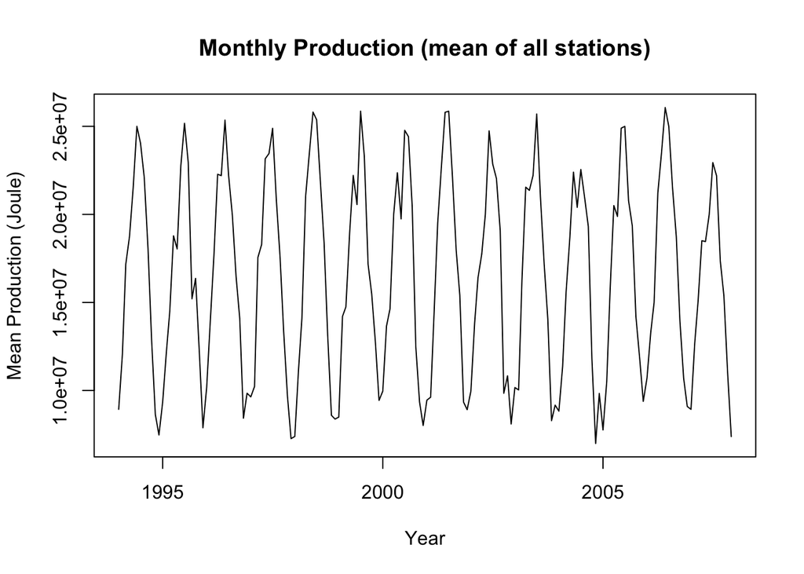

```r
# plot the mean solar production across all stations
solar_data_agg <- data.table(Date = solar_data$Date, all_station_mean = apply(solar_data[,2:99], MARGIN = 1, FUN = mean))
solar_data_agg$Month <- floor_date(solar_data_agg$Date, 'month')
solar_data_agg$Year <- floor_date(solar_data_agg$Date, 'year')

# monthly values
plot(x = solar_data_agg[, list(all_station_mean = mean(all_station_mean)), by = Month]$Month,
     y = solar_data_agg[, list(all_station_mean = mean(all_station_mean)), by = Month]$all_station_mean,
     type = 'l',
     main = 'Monthly Production (mean of all stations)',
     ylab = 'Mean Production (Joule)',
     xlab = 'Year')
```

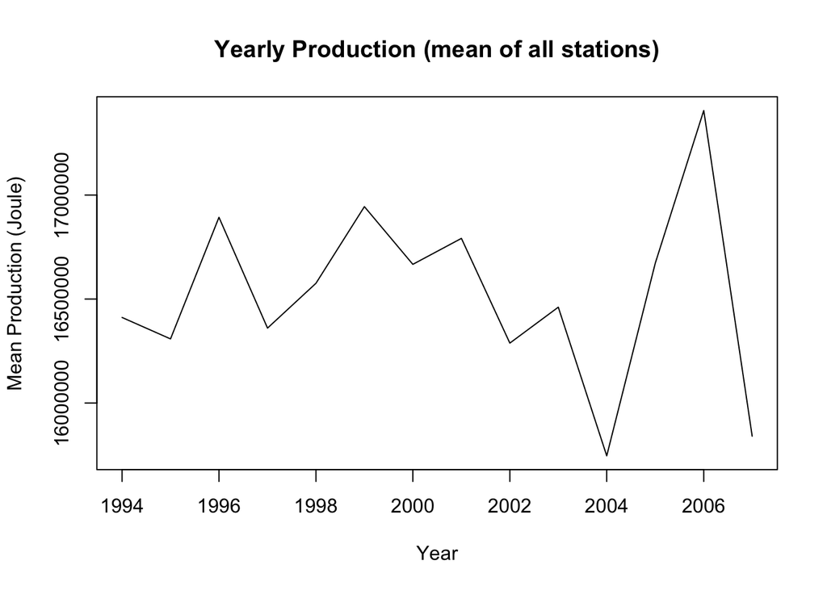

```r
# yearly values
plot(x = solar_data_agg[, list(all_station_mean = mean(all_station_mean)), by = Year]$Year,
     y = solar_data_agg[, list(all_station_mean = mean(all_station_mean)), by = Year]$all_station_mean,
     type = 'l',
     main = 'Yearly Production (mean of all stations)',
     ylab = 'Mean Production (Joule)',
     xlab = 'Year')
```

Principal Components

(file: solar_data)

The following section will analyse the output of the principal component analysis.

To determine the number of principal components we need for modeling, we first get the variance for each column. Plotting the variance confirms that the first principal component has by far the largest variance.

```r
# get variance of each principal component
principal_components <- data.table(
  principal_component = colnames(solar_data[,100:456]),
  variance = sapply(solar_data[,100:456], var)
)

print(head(principal_components, 10))
```

```
##     principal_component   variance
##  1:                 PC1 60256.6584
##  2:                 PC2  8894.9491
##  3:                 PC3  5808.9272
##  4:                 PC4  3148.6047
##  5:                 PC5  2625.0949
##  6:                 PC6  2150.3286
##  7:                 PC7  1721.2762
##  8:                 PC8  1438.5057
##  9:                 PC9  1193.6130
## 10:                PC10   899.6274
```

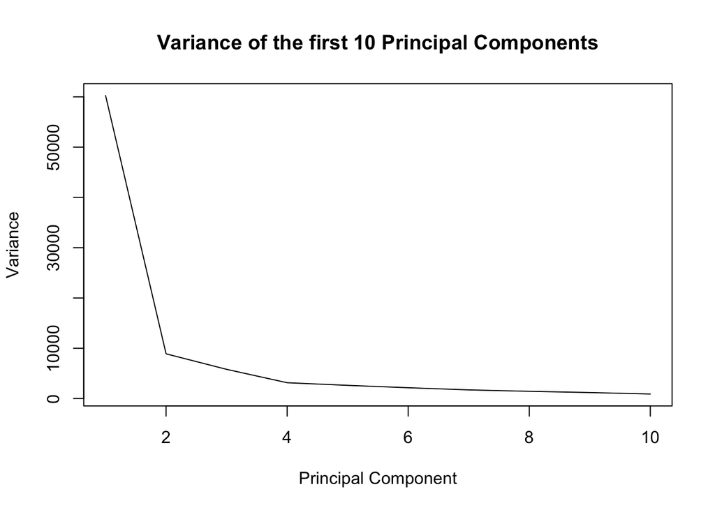

```r
plot(principal_components$variance[1:10],
     type = 'l',
     main = 'Variance of the first 10 Principal Components',
     ylab = 'Variance',
     xlab = 'Principal Component')
```

To decide how many principal components to keep, we calculate the percentage of total variance explained by the principal component, as well as the cumulative percentage of variance explained. We see the following:

| Variance Explained | Number of PCs required |
| --- | --- |
| 70% | 4 |
| 75% | 6 |
| 80% | 10 |
| 85% | 20 |

This shows that we need a growing number of additional principal components to explain an additional 5% of the data.

Based on this, we think it’s best to take the first 10 principal components in our model, which explain 80% of the data.

```r
# get the percentage of total variance that each principal component explains
total_variance = sum(principal_components$variance)
principal_components$perc_of_total_variance <- principal_components$variance / total_variance

# get the cumulative percentage of explained variance
principal_components$cumulative_perc <- cumsum(principal_components$perc_of_total_variance)
print(principal_components)
```

```
##      principal_component    variance perc_of_total_variance cumulative_perc
##   1:                 PC1 60256.65841           0.5472295407       0.5472295
##   2:                 PC2  8894.94908           0.0807807640       0.6280103
##   3:                 PC3  5808.92716           0.0527546105       0.6807649
##   4:                 PC4  3148.60475           0.0285945085       0.7093594
##   5:                 PC5  2625.09487           0.0238401780       0.7331996
##  ---
## 353:               PC353    11.58451           0.0001052064       0.9995760
## 354:               PC354    11.59154           0.0001052703       0.9996813
## 355:               PC355    11.96448           0.0001086571       0.9997900
## 356:               PC356    11.64897           0.0001057918       0.9998958
## 357:               PC357    11.47795           0.0001042386       1.0000000
```

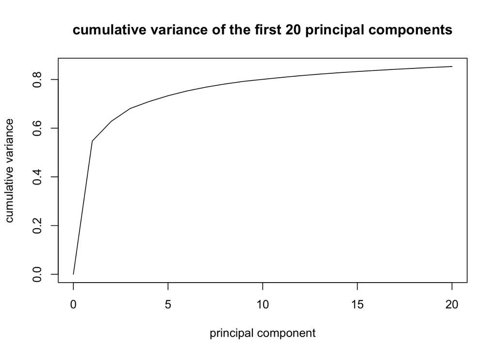

```r
plot(y = c(0, principal_components$cumulative_perc[1:20]),
     x = c(0:20),
     type = 'l',
     main = 'cumulative variance of the first 20 principal components',
     ylab = 'cumulative variance',
     xlab = 'principal component')
```

For additional insights, we want to see the correlations between all principal components and all stations. We see that PC1 has a similar correlation to all stations, but that otherwise there is no pattern. From this we can conclude that we need to develop a different model for each station, since the PCs have a different influence and relationship for the different stations. Also, it suggests that it might be useful to not use the same PCs as inputs for each model.

```r
# create empty data frame to store correlations
correlationsPC <- data.frame()

# calculate correlations
for (iter_station in 2:99){
  for (iter_pc in 100:456){
    correlationsPC[iter_pc - 99, iter_station - 1] <- as.numeric(cor(as.numeric(solar_data[[iter_station]]), as.numeric(solar_data[[iter_pc]]), method = "pearson", use = "complete.obs"))
  }
}

colnames(correlationsPC) <- colnames(solar_data)[2:99]
rownames(correlationsPC) <- colnames(solar_data)[100:456]

# print correlations
print(correlationsPC)
```

[output not shown]

[output cut: 7105 more lines]

```
## PC343 -0.0080079431 -7.860999e-03 -1.452180e-02
## PC344  0.0086027838  1.382908e-02  1.008878e-02
## PC345  0.0101492722 -1.584617e-02 -7.480695e-03
## PC346 -0.0052074470 -4.659024e-03 -2.371014e-03
## PC347  0.0118092779  1.076124e-02  9.736809e-03
## PC348 -0.0043247939 -1.349412e-02 -1.156868e-02
## PC349 -0.0064610273  3.847819e-04 -2.825727e-03
## PC350  0.0027650270 -2.905620e-02  9.121018e-03
## PC351  0.0051708502  1.061732e-02 -6.346127e-03
## PC352 -0.0106641690  1.391582e-02 -9.722159e-04
## PC353 -0.0157719092  8.891124e-03 -1.085987e-02
## PC354  0.0003709030  2.416244e-02  6.244160e-03
## PC355  0.0232230756  6.996483e-03  1.305509e-02
## PC356  0.0114625669  8.946188e-03  1.916722e-02
## PC357 -0.0089373144 -1.565888e-02 -1.673396e-02
```

Additional Variables

(file: additional_variables)

We start by loading the data. Then we inspect it by printing the number of columns, rows and the first 5 rows of each column.

We see that are 100 columns with additional information for each day in the dataset. Many entries are zero and there are some NA entries, so we should investigate those.

```r
# load data and inspect it
additional_variables <- readRDS('/Users/Jonas/Library/Mobile Documents/com~apple~CloudDocs/Documents/MBD/01. Term 1/Programming R/00. GA/additional_variables.RData')
sprintf('Number of rows: %d', nrow(additional_variables))
```

```
## [1] "Number of rows: 6909"
```

```r
sprintf('Number of columns: %d', ncol(additional_variables))
```

```
## [1] "Number of columns: 101"
```

```r
head(additional_variables)
```

| Date | V6409 | V3529 | V649 | V7129 | V2089 | V1369 | V4969 | V5689 | V7849 | V2809 | V4970 | V650 | V7130 | V2810 | V4249 | V5690 | V3530 | V6410 | V2090 | V7850 | V360 | V4250 | V1801 | V1370 | V361 | V1800 | V3961 | V4680 | V3240 | … |
| --- | --- | --- | --- | --- | --- | --- | --- | --- | --- | --- | --- | --- | --- | --- | --- | --- | --- | --- | --- | --- | --- | --- | --- | --- | --- | --- | --- | --- | --- | --- |
| 19940101 | 0.00 | 0.0 | 0.00 | 0 | 0.00 | 0.00 | 0.00 | NA | 0.00 | 0.00 | 0.00 | 0.00 | 0.00 | 0.00 | 0.0 | 0 | 0.0 | 0.00 | 0.0 | 0 | 0 | 0.00 | 0 | 0.00 | 0 | 0 | 0 | 0 | 0 | … |
| 19940102 | 0.37 | 0.1 | 0.14 | 0 | 0.04 | 0.42 | 0.04 | 0 | 0.17 | 0.05 | 0.04 | 0.14 | 0.08 | 0.12 | 0.2 | 0 | 0.2 | 0.43 | 0.2 | NA | 0 | 0.31 | 0 | 0.58 | 0 | 0 | 0 | 0 | 0 | … |
| 19940103 | 0.00 | 0.0 | 0.00 | 0 | 0.00 | 0.00 | 0.00 | 0 | 0.00 | 0.00 | 0.00 | 0.00 | 0.00 | 0.00 | 0.0 | 0 | 0.0 | 0.00 | 0.0 | 0 | 0 | 0.00 | 0 | 0.00 | 0 | 0 | 0 | 0 | 0 | … |
| 19940104 | 0.00 | 0.0 | 0.00 | 0 | 0.00 | 0.00 | 0.00 | 0 | 0.00 | 0.00 | 0.00 | 0.00 | 0.00 | 0.00 | 0.0 | 0 | 0.0 | 0.00 | 0.0 | 0 | 0 | 0.00 | 0 | 0.00 | 0 | 0 | 0 | 0 | 0 | … |
| 19940105 | 0.00 | 0.0 | 0.00 | 0 | 0.00 | 0.00 | 0.00 | 0 | NA | NA | NA | 0.00 | 0.00 | 0.00 | 0.0 | 0 | 0.0 | 0.00 | 0.0 | 0 | 0 | 0.00 | 0 | NA | 0 | 0 | 0 | 0 | 0 | … |
| 19940106 | 0.00 | 0.0 | 0.00 | 0 | 0.00 | 0.00 | 0.00 | 0 | 0.00 | NA | 0.00 | 0.00 | 0.00 | 0.00 | 0.0 | 0 | 0.0 | 0.00 | 0.0 | 0 | 0 | 0.00 | 0 | 0.00 | 0 | 0 | 0 | 0 | 0 | … |

We start by finding the percentage of missing values. For all columns, the number of missing values is <10%.

```r
# find number of missing values per column
data.table(
  column = colnames(additional_variables[,2:101]),
  n_missing = round(100 * sapply(data.table(sapply(additional_variables[,2:101], is.na)), mean), 2))
```

| column | n_missing |
| --- | --- |
| V6409 | 6.22 |
| V3529 | 0.48 |
| V649 | 2.00 |
| V7129 | 6.61 |
| V2089 | 2.87 |
| V1369 | 0.16 |
| V4969 | 3.88 |
| V5689 | 6.41 |
| V7849 | 1.95 |
| V2809 | 4.88 |

[output cut: 90 more lines]

Next, we investigate the values which are zero. To do that, we create a custom function which finds zero, just like is.na() finds NAs.

The results show that all columns have around 70-75% of values which equal zero. This is very important, since it means that the dataset doesn’t contain a lot of information. Also, some types of models like neural networks don’t deal well with sparse data.

```r
# find number of values equal to zero per column
is.zero <- function(input){
  output <- input == 0
  return(output)
}

data.table(
  column = colnames(additional_variables[,2:101]),
  n_zero = round(100 * sapply(data.table(sapply(additional_variables[,2:101], is.zero)), mean, na.rm = TRUE), 2))
```

| column | n_zero |
| --- | --- |
| V6409 | 74.92 |
| V3529 | 74.55 |
| V649 | 74.77 |
| V7129 | 74.77 |
| V2089 | 75.09 |
| V1369 | 74.79 |
| V4969 | 74.51 |
| V5689 | 74.67 |
| V7849 | 75.11 |
| V2809 | 74.33 |

[output cut: 90 more lines]

To deal with the NA values, we do a linear imputation. We chose the linear imputation because in a time series, it is a good assumption that the value of a data point is between it predecessor and successor.

```r
# impute missing values
additional_variables <- data.frame(
  Date = additional_variables$Date,
  sapply(additional_variables[,2:101], na_interpolation, option = 'linear'))

# confirm there are no more missing columns
data.table(
  column = colnames(additional_variables[,2:101]),
  n_missing = sapply(data.table(sapply(additional_variables[,2:101], is.na)), sum))
```

| column | n_missing |
| --- | --- |
| V6409 | 0 |
| V3529 | 0 |
| V649 | 0 |
| V7129 | 0 |
| V2089 | 0 |
| V1369 | 0 |
| V4969 | 0 |
| V5689 | 0 |
| V7849 | 0 |
| V2809 | 0 |

[output cut: 90 more lines]

Station Info

(file: station_info)

First, we calculate the mean energy output of each station and join the two datasets to compare the mean solar output to the location. We show the data to inspect it.

```r
# find mean of each solar output column
station_mean <- solar_data[, sapply(.SD, mean, na.rm = TRUE), .SDcols = colnames(solar_data[,2:99])]
station_mean <- data.table(station = colnames(solar_data[,2:99]), mean_production_per_station = station_mean)

# join both station_info and station_mean
geodata <- merge(station_info,
                 station_mean,
                 by.x = 'stid',
                 by.y = 'station')

# inspect data
head(geodata)
```

| stid | nlat | elon | elev | mean_production_per_station |
| --- | --- | --- | --- | --- |
| ACME | 34.80833 | -98.02325 | 397 | 16877462 |
| ADAX | 34.79851 | -96.66909 | 295 | 16237534 |
| ALTU | 34.58722 | -99.33808 | 416 | 17119189 |
| APAC | 34.91418 | -98.29216 | 440 | 17010565 |
| ARNE | 36.07204 | -99.90308 | 719 | 17560173 |
| BEAV | 36.80253 | -100.53012 | 758 | 17612143 |

Next, we create a map of the mean energy production for each station. It has a color code from low production (light red) to high production (dark red).

We see that there is a clear pattern, showing higher energy productions towards the west of the state.

```r
# create a color palette for the map
pal <- colorBin(palette = 'Reds',
                domain = c(min(geodata$mean_production_per_station),
                           max(geodata$mean_production_per_station)))

# create the map
leaflet() %>%
  addProviderTiles('CartoDB.Positron') %>%
  addCircleMarkers(lng = geodata$elon,
                   lat = geodata$nlat,
                   popup = paste0('Production: ', round(geodata$mean_production/1000000, 2), ' MJ'),
                   radius = 5,
                   opacity = 0.5,
                   fillOpacity = 0.5,
                   color = pal(geodata$mean_production_per_station)) %>%
  addLegend(title = 'mean energy production (mega joule)',
            position = 'topright',
            pal = pal,
            values = c(min(geodata$mean_production_per_station),
                       max(geodata$mean_production_per_station)))
```

[interactive chart not shown]

Our hypothesis is that this trend might be related to the elevation. Therefore, we produce the same graph with elevation instead of energy production in the color code.

We see the same trend, which shows that there is a high correlation between elevation and mean energy production. We calculate the correlation to get the exact value, which is 0.85.

This value is extremely useful for modeling, since all other data is general weather data and there was no way to differentiate between stations. Now, we have a strong way to differentiate between stations.

```r
# repeat the same plotting the elevation
pal2 <- colorBin(palette = 'Reds',
                 domain = c(min(geodata$elev),
                            max(geodata$elev)))

leaflet() %>%
  addProviderTiles('CartoDB.Positron') %>%
  addCircleMarkers(lng = geodata$elon,
                   lat = geodata$nlat,
                   popup = paste0('Elevation: ', geodata$elev, ' meter'),
                   radius = 5,
                   opacity = 0.5,
                   fillOpacity = 0.5,
                   color = pal2(geodata$elev)) %>%
  addLegend(title = 'elevation (meter)',
            position = 'topright',
            pal = pal2,
            values = c(min(geodata$elev),
                       max(geodata$elev)))
```

[interactive chart not shown]

```r
# get correlation between elevation and energy production
sprintf('Correlation: %g',
        round(cor(geodata$elev, geodata$mean_production_per_station), 2))
```

```
## [1] "Correlation: 0.85"
```

Conclusion

In conclusion, the only differentiating feature between the stations is its elevation. The higher the station, the higher the average energy production. However, if we create a unique model for each station, this feature won’t be relevant anymore, since it would become a constant input.

The additional variables might be helpful, but because the data is so sparse (~75% values are zeros), a PCA of this data might be more useful.

For the principal components (PCs) from the main dataset, the first 20 explain 85% of the variance. However, the correlations between the PCs and the stations are not the same for all stations. Therefore, it might be useful in the modeling stage to find the most relevant PCs for each station. Nonetheless, due to non-linear interactions between PCs, it would also be a valid assumption to take the first 20, as they contain the most information.